# FordGoBike Dataset

## I have chosen to work on the FordGoBike dataset. And for this reason I will need to upload the data inot Jupytor notebook to start exploration and explanation process.

### How does the Dataset Structure ?

- The data we are evaluating is for FordGoBike 2019,
- We have cleaned the data and saved it under a new folder called bikes_clean.
- bikes_clean dataset constitue of 174952 rows , and 10 columns.

### What are the main features we will investigate in our exploratory plotting?

- Duration of each trip, customer type, gender, birthday, days of the week

### What type of features will be used to create univariate and multivariate plots for both exploratory and explanatory purposes?

- Category data related to days, gender, top 15 station names
- Numerical data that is mainly the colum related with duration of each trip

# Univariate plotting

## Eploratory and Explanatory analysis

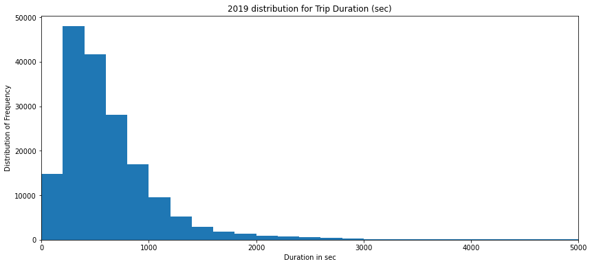

```python
# Plotting the first numerical distribution value, using a histogram

plt.figure(figsize = [14, 6])

bins = np.arange(0, bikes_clean['duration_sec'].max()+200, 200)
plt.hist(data = bikes_clean, x = 'duration_sec', bins = bins)
plt.xlim(0, 5000)
plt.title('2019 distribution for Trip Duration (sec)')
plt.xlabel('Duration in sec')
plt.ylabel('Distribution of Frequency');
```

- The distribution is right skewed, showing that most of the trips happen for a period less than half and hor,
- This suggest to use a log distribution to reconfirm if the hist will change distribution model.

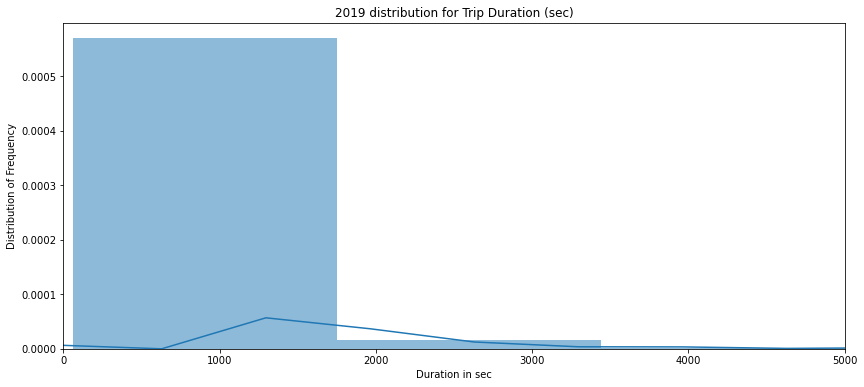

```python
# additiona evaluation for ths data using the distribution plot
# This will help plot the line curve of the time distribution using the mean averages

plt.figure(figsize = [14, 6])
sb.distplot(bikes_clean['duration_sec'], kde = True, hist_kws = {'alpha' : 0.5})
plt.xlim(0, 5000)
plt.title('2019 distribution for Trip Duration (sec)')
plt.xlabel('Duration in sec')
plt.ylabel('Distribution of Frequency');
```

- The distribution plot confirms that the data is skewed toward the half and hour and less, So lets look at the log scale type and reconfirm how the time is been distributed amongst the scale.

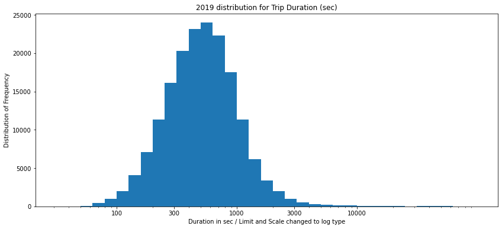

```python
# Plot the new log distribution
# Define the figure size
# Define the ticks and labels for the y axis

plt.figure(figsize = [14, 6])
bins_log = 10 ** np.arange(1.5, 5+0.1, 0.1)
ticks = [100, 300, 1000, 3000, 10000]
labels = ['{}'.format(v) for v in ticks]

plt.hist(data = bikes_clean, x = 'duration_sec', bins = bins_log)
plt.xscale('log')
plt.xticks(ticks, labels)
plt.title('2019 distribution for Trip Duration (sec)')
plt.xlabel('Duration in sec / Limit and Scale changed to log type')
plt.ylabel('Distribution of Frequency');
```

- After Applying the log scale type, the hist shape shows that the data now are almost evenly distributed. And a bit skewed for the less than half hour duration, mainly between 5 and 10 min.

### Lets try to get a normat distribution for both genders

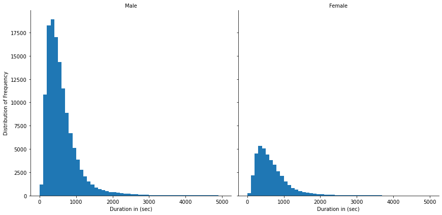

```python
# Creat a FacetGrid to plot both female and male histograms next to each other

g = sb.FacetGrid(data = bikes_sub, col = 'member_gender', col_wrap = 2, height = 6, sharex = True,
                 sharey = True)
g.map(plt.hist, 'duration_sec', bins = bins_adj)
g.set_titles('{col_name}')
g.set_ylabels('Distribution of Frequency')
g.set_xlabels('Duration in (sec)');
```

Both genders shows a right skewed distribution, However, the mails shows a higher spike within the distribution confirming a more frequent usage of the bike service.

The only comon point is that the period of usuage for both genders still in favor of less than half and hour and mainly focused on a 5 to 8 min durations

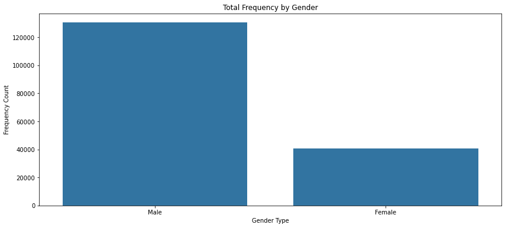

```python
# Creat a count plot for both Genders
# Set color code to base color

base_color = sb.color_palette()[0]
plt.figure(figsize = [14, 6])


sb.countplot(data = bikes_sub, x = 'member_gender', color = base_color)
plt.title('Total Frequency by Gender')
plt.xlabel('Gender Type')
plt.ylabel('Frequency Count');
```

- It is clear that males are more frequent users for bikes compared to females
  - I have dropped the others since they are small to be represeted and dropping them will not effect the outcome of the plot

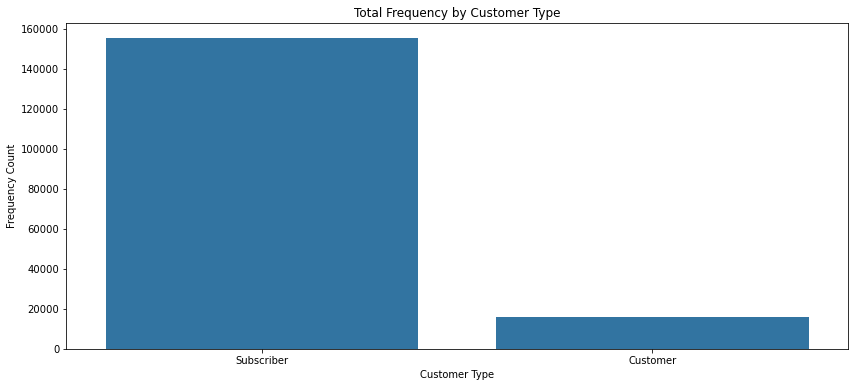

```python
# Create a count plot for the customer type category

plt.figure(figsize = [14, 6])

sb.countplot(data = bikes_sub, x = 'user_type', color = base_color)
plt.title('Total Frequency by Customer Type')
plt.xlabel('Customer Type')
plt.ylabel('Frequency Count');
```

- The service is heavily depended on subscribers rather than adhoc users, which means that more marketing and insentives has be provided to convert more new Sunscribers.
- And probably at the same time, what need to be done from services to marketing to attract more female Sunscribers and Customers. Need to investigate this in more details

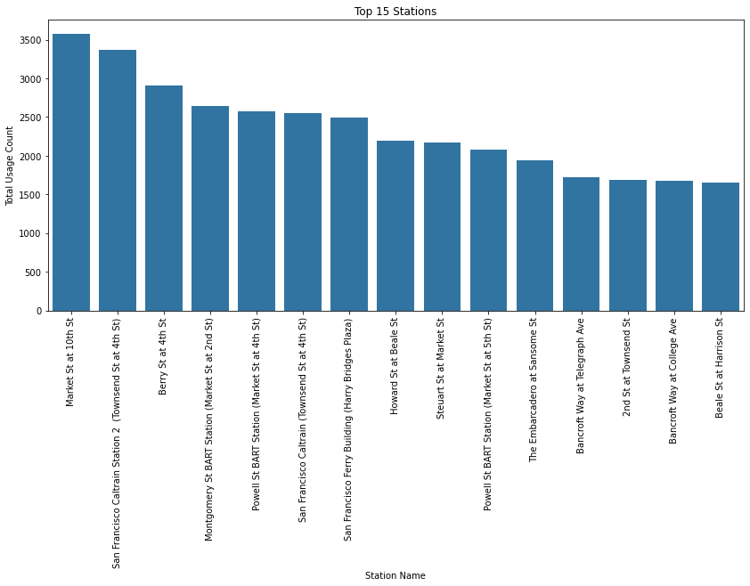

```python
# Plot the top 15 stations using the countplot

plt.figure(figsize = [14, 6])

sb.countplot(data = bikes_sub, x = 'start_station_name', color = base_color, order = station_ord)
plt.xticks(rotation = 90)
plt.title('Top 15 Stations')
plt.xlabel('Station Name')
plt.ylabel('Total Usage Count');
```

- Need to understand the capacity of these locations, also what is needed to inrease the frequency and the leads for the other locations to par with the top performong locations

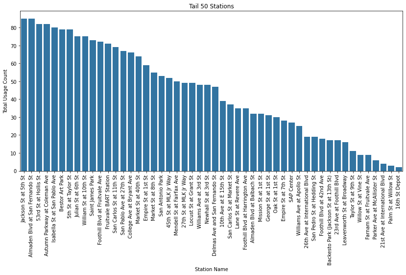

```python
# Plotting the least used start stations

plt.figure(figsize = [14, 6])

sb.countplot(data = bikes_sub, x = 'start_station_name', color = base_color, order = tail_ord)
plt.xticks(rotation = 90)
plt.title('Tail 50 Stations')
plt.xlabel('Station Name')
plt.ylabel('Total Usage Count');
```

- The best thing is to do a custom audience and station segmentation to evaluate the threshold curve and capacity.
- This will help push activity to improve station lead perfomance

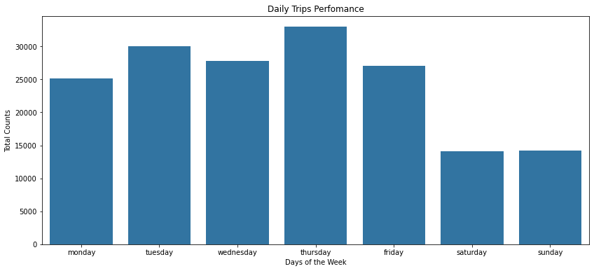

```python
# Creat a day of the week usage
# Keep the categorical order for the days to better check day performance changes

plt.figure(figsize = [14, 6])

sb.countplot(data = bikes_sub, x = 'day', color = base_color)
plt.xticks()
plt.title('Daily Trips Perfomance')
plt.xlabel('Days of the Week')
plt.ylabel('Total Counts');
```

- Weekends seams to be the least frequent days for bike services.
- Which ultimately, can confirm that half of the services is done for work related trips rather than leasure, again this explains the fact of smaller duration for transportation.

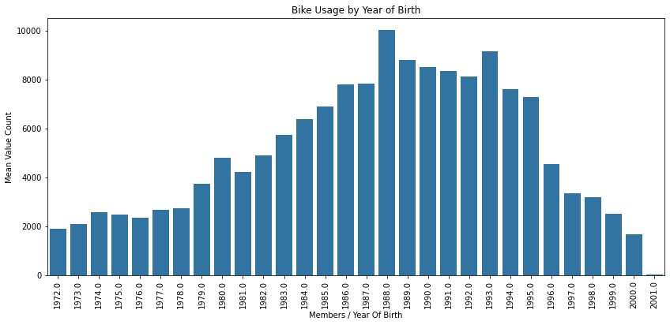

```python
# Plot the age freuqncy of usage distribution

plt.figure(figsize = [14, 6])

sb.countplot(data = bikes_sub, x = 'member_birth_year', color = base_color, order = age_order)
plt.xticks(rotation = 90)
plt.title('Bike Usage by Year of Birth')
plt.xlabel('Members / Year Of Birth')
plt.ylabel('Mean Value Count');
```

- Most of the users ages are between 36 and 24 year old with more skew towards the elder age braket, this might confirm the fact it is used for interim business commuting.
- Probably a more indepth investigation need to be made for indepth usage analysis and gender.

# Mutlivariate Plotting

## Explanatory analysis

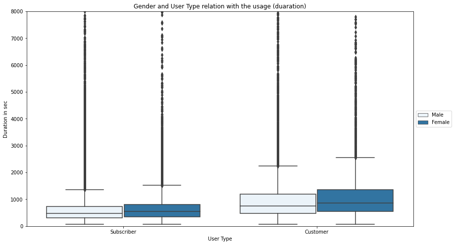

```python
# Define base color to use
# Define plot size

base_color = sb.color_palette()[0]
plt.figure(figsize = [14, 8])

# Use the box plot to understand categorical relation with numerical data of duration
# Due to high outliers, we have plut a lim to y axis for better reading

sb.boxplot(data = bikes_sub, x ='user_type', y = 'duration_sec', hue='member_gender', color = base_color)
plt.xticks()
plt.yticks()
plt.ylim(0, 8000)
plt.title('Gender and User Type relation with the usage (duaration)')
plt.legend(loc = 6, bbox_to_anchor = (1.0, 0.5));
plt.xlabel('User Type')
plt.ylabel('Duration in sec');
```

### Understanding the gender and type category relation with time spend using the bikes.

- The Customer in the type category has a higher averages of time spend using the bikes compared to sunscirbers
- This would reconfirm that subscribers are more frequennt users for work related matters
- Also that the Subscribers are familiar with the service and can adapt faster compared to Customers

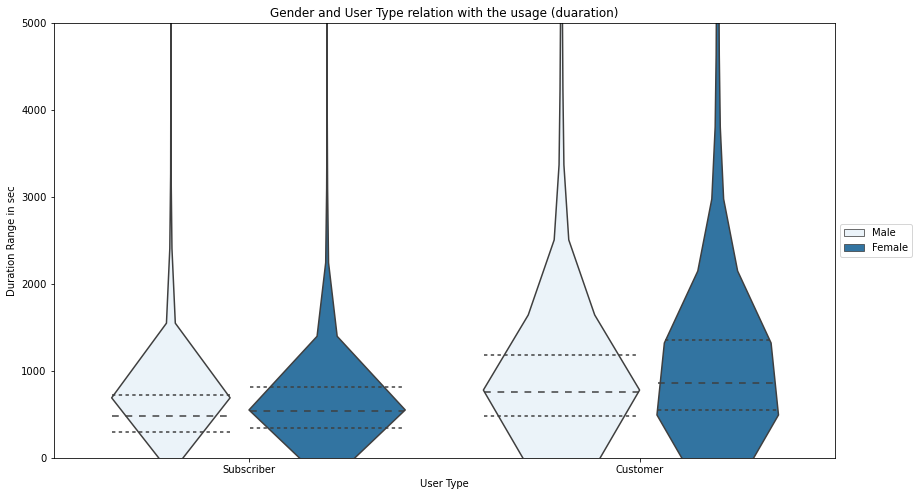

```python
# Define base color to use
# Define plot size

base_color = sb.color_palette()[0]
plt.figure(figsize = [14, 8])

# Investigate further the data using violin plot
# This will help understand better the voluim of this distrbution against the quartile values

sb.violinplot(data = bikes_sub, x ='user_type', y = 'duration_sec', hue='member_gender', color = base_color,
             inner = 'quartile')
plt.xticks()
plt.yticks()
plt.ylim(0, 5000)
plt.legend(loc = 6, bbox_to_anchor = (1.0, 0.5))

plt.title('Gender and User Type relation with the usage (duaration)')
plt.xlabel('User Type')
plt.ylabel('Duration Range in sec');
```

### As a conclusion, males are more frequent users for the bike service and share a lower average time compared to females.

## Using a bivariate plotting to analyse time distribution by day of the week against gender and customer type category.

- Kept in this sequence as it the serves flow of analysis, for a better story telling

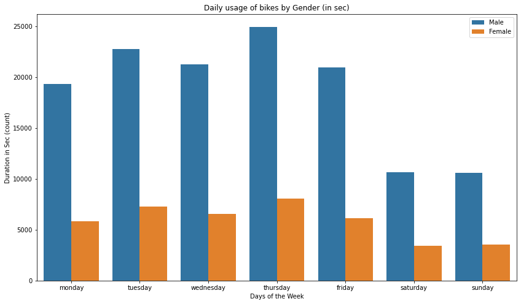

```python
# Set two categorical values against days of the week
# Best to use the count plot

plt.figure(figsize = [14, 8])
sb.countplot(data = bikes_sub, x = 'day', hue = 'member_gender')

plt.xticks()
plt.yticks()
plt.legend()

plt.title('Daily usage of bikes by Gender (in sec)')
plt.xlabel('Days of the Week')
plt.ylabel('Duration in Sec (count)');
```

- While Thursday, Tuesday and Wednesday are top days of usage accross the week
- Weekends seams in par of usage against the gender and value count fo usage in sec. This might be instigate by a cirtain behavior worth investigating.

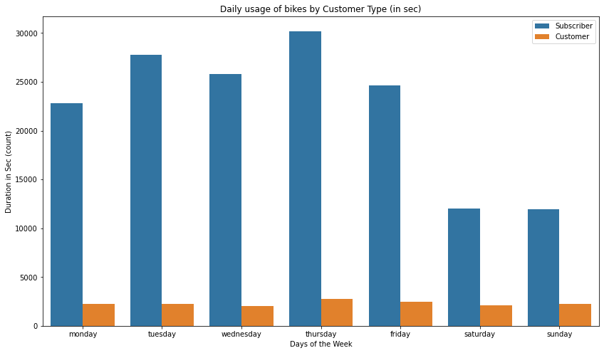

```python
# Evaluate cutomer type against day of the week and duration

plt.figure(figsize = [14, 8])
sb.countplot(data = bikes_sub, x = 'day', hue = 'user_type')

plt.xticks()
plt.yticks()
plt.legend()

plt.title('Daily usage of bikes by Customer Type (in sec)')
plt.xlabel('Days of the Week')
plt.ylabel('Duration in Sec (count)');
```

### For customer type, Subscribers usage of bikes dominates, by far, across all days of the week

- Here we could also withness same trend over the weekend. Thus a more indepth analysis is we needed to understand the category's lead generation approach.

# Back to multivariate plotting.

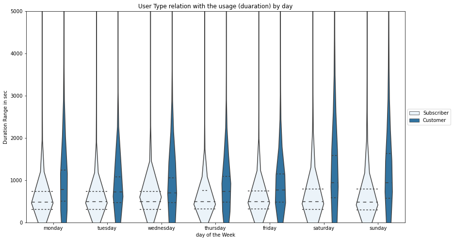

```python
# Define base color to use
# Define plot size

base_color = sb.color_palette()[0]
plt.figure(figsize = [14, 8])

# Check additional distribution of duration against customer type and day of the week
# Use the quartile to understand value to measure correlation change across teh day of the week

sb.violinplot(data = bikes_sub, x ='day', y = 'duration_sec', hue='user_type', color = base_color,
             inner = 'quartile')
plt.xticks()
plt.yticks()
plt.ylim(0, 5000)
plt.legend(loc = 6, bbox_to_anchor = (1.0, 0.5))

plt.title('User Type relation with the usage (duaration) by day')
plt.xlabel('day of the Week')
plt.ylabel('Duration Range in sec');
```

## Mutlivariate plotting for time distirbution against customer type by day

- it relationship is consistent even on weekwends.

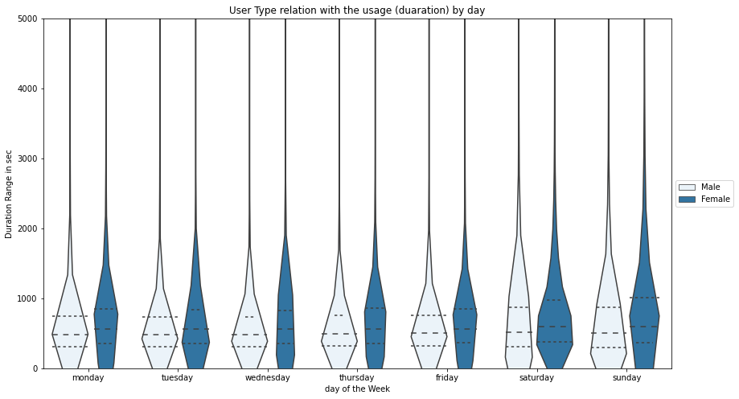

```python
# Define base color to use
# Define plot size

base_color = sb.color_palette()[0]
plt.figure(figsize = [14, 8])

# Use the violin plot to anlyse duration distribution across days of the week by customer type

sb.violinplot(data = bikes_sub, x ='day', y = 'duration_sec', hue='member_gender', color = base_color,
             inner = 'quartile')
plt.xticks()
plt.yticks()
plt.ylim(0, 5000)
plt.legend(loc = 6, bbox_to_anchor = (1.0, 0.5))

plt.title('User Type relation with the usage (duaration) by day')
plt.xlabel('day of the Week')
plt.ylabel('Duration Range in sec');
```